# Vector Data Homework

Is the urban–suburban divide real?

Author

Published

October 15, 2026

Abstract

A sentence or two saying what the document does: the dogwood data, the land cover in each tree’s neighborhood, and whether the urban and suburban habitats really differ.

## The Idea

One of the central habits of reproducible research is that the **words and the code that produce them are written together**. A paragraph of *Methods* is followed immediately by the chunk that carries out what it describes. A sentence in *Results* is backed by a table or figure generated in the chunk beside it, and every number that appears in the running text is read straight from a variable in memory with an inline `` `r ` `` expression — never typed by hand.

In class, we built neighborhoods around 15 of the dogwood trees and measured the land cover inside them. Here you will take the same workflow to **all 58 trees**. The trees were sorted into three habitats: `Native` trees in Pocahontas State Park, and cultivars split at 37.45°N into `Urban` (north) and `Suburban` (south). The `Native` trees are obviously in a different landscape. Your job is to decide whether the line between `Urban` and `Suburban` is a real difference in the landscape the trees live in, or just a line we drew.

Read the worked example, which compares the two types of maternal trees (`Mother`), then reproduce its structure for the three `Habitat`s.

## A Worked Example

### Methods

> **Data.** We used the locations of 58 maternal dogwood trees sampled along a transect from the city of Richmond, Virginia south to Pocahontas State Park, stored as a CSV in the course data repository. Each tree is recorded as either a `Cultivar` or a `Native` maternal tree (`Mother`). We converted the coordinates into spatial points and reprojected them into UTM Zone 17N so that distances are in meters.

```r
library( sf )
library( tidyverse )
library( knitr )
library( kableExtra )

url <- "https://dyerlabteaching.github.io/CourseData/Spatial/Richmond_Dogwoods.csv"

read_csv( url ) |>
  st_as_sf( coords = c("Longitude", "Latitude"),
            crs = 4326 ) |>
  st_transform( crs = 32617 ) -> trees
```

> **Analysis.** We defined each tree’s neighborhood as the area within 250 m of it and measured the proportion of each neighborhood in seven land cover categories from the 2021 National Land Cover Database using the course `get_landcover()` function. We then averaged those proportions across the trees of each type.

```r
source( "https://dyerlabteaching.github.io/Vector-Data/get_landcover.R" )

trees |>
  st_buffer( dist = 250 ) |>
  get_landcover() -> lc

lc |>
  group_by( Mother, Category ) |>
  summarize( Proportion = mean( Proportion ),
             .groups = "drop" ) -> mother_lc
```

### Preparing the reporting values

Before writing the Results, pull the handful of numbers you are going to quote out of the summary and format them here, giving each a short name.

```r
n_cultivar <- sum( trees$Mother == "Cultivar" )
n_native   <- sum( trees$Mother == "Native" )

cultivar_dev <- mother_lc |>
  filter( Mother == "Cultivar", Category == "Developed" ) |>
  pull( Proportion )
native_forest <- mother_lc |>
  filter( Mother == "Native", Category == "Forest" ) |>
  pull( Proportion )

cultivar_dev  <- format( 100 * cultivar_dev, digits = 2 )
native_forest <- format( 100 * native_forest, digits = 2 )
```

### Results

> The two types of maternal trees live in very different landscapes (Table 1, Figure 1). On average, the neighborhoods of the 32 cultivated trees were 84% developed, while those of the 26 native trees were 83% forest.

```r
mother_lc |>
  pivot_wider( names_from = Mother,
               values_from = Proportion ) |>
  kable( digits = 3 ) |>
  kable_paper( "striped", full_width = FALSE )
```

Table 1: Average proportion of each land cover category within 250 m of cultivated and native maternal dogwood trees.

| Category | Cultivar | Native |
| --- | --- | --- |
| Agriculture | 0.007 | 0.006 |
| Barren | 0.001 | 0.004 |
| Developed | 0.838 | 0.051 |
| Forest | 0.102 | 0.835 |
| Shrub/Grass | 0.003 | 0.006 |
| Water | 0.004 | 0.012 |
| Wetland | 0.045 | 0.086 |

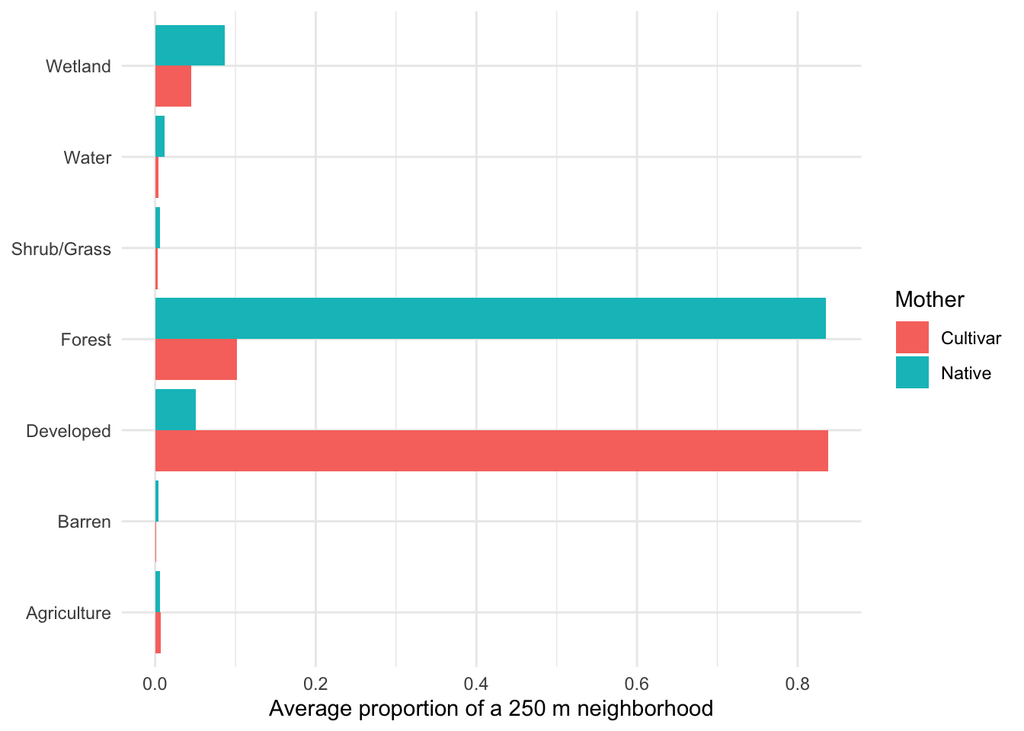

Figure 1: Average proportion of each land cover category within 250 m of cultivated and native maternal dogwood trees.

```r
ggplot( mother_lc,
        aes( Category, Proportion, fill = Mother ) ) +
  geom_col( position = "dodge" ) +
  coord_flip() +
  labs( x = NULL,
        y = "Average proportion of a 250 m neighborhood" ) +
  theme_minimal()
```

Here is the literal source of that Results paragraph — note that every number is an inline expression:

```
The two types of maternal trees live in very different landscapes (@tbl-mother, @fig-mother). On average, the neighborhoods of the `r n_cultivar` cultivated trees were `r cultivar_dev`% developed, while those of the `r n_native` native trees were `r native_forest`% forest.
```

## Your Assignment

Use all 58 trees and the same 250 m neighborhoods to compare the three `Habitat`s, and decide whether the `Urban` and `Suburban` habitats are really different.[^1]

### Your document must have

1. **Methods** — a *Data* paragraph followed by the chunk that reads the CSV and makes the spatial points (in a projection whose units are meters), then an *Analysis* paragraph followed by the chunk that builds the neighborhoods, gets their land cover, and summarizes it by `Habitat`.
2. **A map** of the trees’ neighborhoods colored by `Habitat`, with `geom_sf()`.
3. **A reporting-values chunk** — `format()` the numbers you quote in the Results, and give each a short name.
4. **One publication-quality table**, built with `kable()` and `kableExtra`, of the average proportion of each land cover category in each `Habitat` (one column per `Habitat`).
5. **A bar chart** of the same information.
6. **A north–south plot** of the proportion of `Developed` land cover in each *cultivated* tree’s neighborhood (y-axis) against the tree’s `Latitude` (x-axis), with the points colored by `Habitat`. By default, `st_as_sf()` removes the coordinate columns when it makes the points. Add `remove = FALSE` to keep `Latitude` as a regular column; it then rides along through `st_buffer()` and `get_landcover()` like the rest of each tree’s data. Add `geom_vline( xintercept = 37.45, linetype = "dashed" )` to show where the habitats were split.
7. **Results** — a paragraph that reports your numbers as bare inline `` `r ` `` values (no `format()` in the prose) and refers to your map, table, and figures using Quarto’s cross-reference system (`#| label: tbl-...` / `#| tbl-cap:` and `#| label: fig-...` / `#| fig-cap:` in the chunks, and `@tbl-...` / `@fig-...` in the sentences).[^2]
8. **An interpretation** — a paragraph answering the question: *Is the divide between `Urban` and `Suburban` dogwoods a real difference in the landscape they live in?* Use your table and your north–south plot to support your answer. Think about both the averages *and* how much the individual trees in the two habitats overlap.

Then answer briefly, a sentence or two each:

- What units is the `250` in `st_buffer( dist = 250 )`, and how can you tell from the `trees` object? Why did we reproject into UTM first rather than buffering the points in their original longitude/latitude (`EPSG:4326`)?
- Your table *averages* the proportions across each tree’s neighborhood. If you instead unioned all the neighborhoods in a habitat into a single polygon and got the land cover of that, how could the answer differ, and why?

## What You Turn In

**One file: the rendered, self-contained `.html`.** Not the `.qmd`, and not a copy of this page. Make a *new* Quarto document that contains only your own work — your Methods and Results sections with their chunks, the reporting-values chunk, your map, table, and figures, your interpretation, and your brief answers to the two questions.

The worked example above is a model to imitate, not text to paste into your document.

### Making the document

1. In RStudio: **File ▸ New File ▸ Quarto Document…**
2. In the dialog, enter a title and your name, leave the engine set to **Knitr**, and click **Create**.
3. Delete everything RStudio puts below the header (the “Quarto” boilerplate and its example chunk).
4. Replace the header it generated with the one below.
5. Save the file into your course project folder as `Vector-Data-Homework.qmd`.
6. Write your content, then click **Render** to produce the `.html`. That HTML file is what you submit.

### The full YAML header

```yaml
---
title: "Vector Data Homework"
author: "Your Name"
date: today
abstract: |
  A sentence or two saying what the document does: the data, the question, and what you found.
format:
  html:
    self-contained: true
    code-tools: true
---
```

- **`title` / `author` / `date` / `abstract`** — complete front matter, including a short summary where a scientific paper would put its abstract. `date: today` fills itself in at render time.
- **`format: html`** — render to a single web page I can open in any browser.
- **`self-contained: true`** — bundle every image, style, and script *into* that one `.html` file. Without it the file depends on a sibling `*_files/` folder that never makes it into the upload, and your figures and formatting arrive broken.
- **`code-tools: true`** — adds the “</> Code” button in the top-right that lets a reader view the full source. **This is not optional.** If I cannot see the code behind a wrong answer, I cannot tell whether you were one typo away or lost the plot entirely — which means I cannot give partial credit, point out where it went sideways, or help you fix it.

Use this same header layout for every document you turn in this course.

## How This Is Graded

This assignment is scored with the **Online Homework Rubric** on the Canvas site — the same rubric used for every online homework in this course. It covers online access to the published document, front matter, formatting, and whether the document stands on its own; the remaining points come from the assignment-specific work above.

## Footnotes

[^1]: Every step is in the module [narrative](https://dyerlabteaching.github.io/Vector-Data/narrative.html) (sections *Buffers and Neighborhoods* and *Land Cover*) and in what you did in the in-class activity.
[^2]: Cross-referencing tables is in the [Tidyverse](https://dyerlabteaching.github.io/Tidyverse/narrative.html#cross-referencing-tables-in-text) narrative; figures work the same way with a `fig-` label and a `fig-cap`.